# Risk Factor Analysis

## Outcome Variable

**Outcome Variable:** wast_rec90d

## Predictor Variables

**Intervention Variable:** vagbrth

**Adjustment Set:**

unadjusted

## Stratifying Variables

The analysis was stratified on these variable(s):

- agecat
- studyid
- country

## Data Summary

| agecat | studyid | country | vagbrth | wast_rec90d | n_cell | n | outcome_variable |
| --- | --- | --- | --- | --- | --- | --- | --- |
| 0-24 months | ki1000108-CMC-V-BCS-2002 | INDIA | 0 | 0 | 11 | 324 | wast_rec90d |
| 0-24 months | ki1000108-CMC-V-BCS-2002 | INDIA | 0 | 1 | 9 | 324 | wast_rec90d |
| 0-24 months | ki1000108-CMC-V-BCS-2002 | INDIA | 1 | 0 | 109 | 324 | wast_rec90d |
| 0-24 months | ki1000108-CMC-V-BCS-2002 | INDIA | 1 | 1 | 195 | 324 | wast_rec90d |
| 0-24 months | ki1000108-IRC | INDIA | 0 | 0 | 24 | 395 | wast_rec90d |
| 0-24 months | ki1000108-IRC | INDIA | 0 | 1 | 39 | 395 | wast_rec90d |
| 0-24 months | ki1000108-IRC | INDIA | 1 | 0 | 138 | 395 | wast_rec90d |
| 0-24 months | ki1000108-IRC | INDIA | 1 | 1 | 194 | 395 | wast_rec90d |
| 0-24 months | ki1017093b-PROVIDE | BANGLADESH | 0 | 0 | 25 | 308 | wast_rec90d |
| 0-24 months | ki1017093b-PROVIDE | BANGLADESH | 0 | 1 | 44 | 308 | wast_rec90d |
| 0-24 months | ki1017093b-PROVIDE | BANGLADESH | 1 | 0 | 104 | 308 | wast_rec90d |
| 0-24 months | ki1017093b-PROVIDE | BANGLADESH | 1 | 1 | 135 | 308 | wast_rec90d |
| 0-24 months | ki1017093c-NIH-Crypto | BANGLADESH | 0 | 0 | 18 | 189 | wast_rec90d |
| 0-24 months | ki1017093c-NIH-Crypto | BANGLADESH | 0 | 1 | 42 | 189 | wast_rec90d |
| 0-24 months | ki1017093c-NIH-Crypto | BANGLADESH | 1 | 0 | 58 | 189 | wast_rec90d |
| 0-24 months | ki1017093c-NIH-Crypto | BANGLADESH | 1 | 1 | 71 | 189 | wast_rec90d |
| 0-24 months | ki1066203-TanzaniaChild2 | TANZANIA, UNITED REPUBLIC OF | 0 | 0 | 24 | 705 | wast_rec90d |
| 0-24 months | ki1066203-TanzaniaChild2 | TANZANIA, UNITED REPUBLIC OF | 0 | 1 | 32 | 705 | wast_rec90d |
| 0-24 months | ki1066203-TanzaniaChild2 | TANZANIA, UNITED REPUBLIC OF | 1 | 0 | 240 | 705 | wast_rec90d |
| 0-24 months | ki1066203-TanzaniaChild2 | TANZANIA, UNITED REPUBLIC OF | 1 | 1 | 409 | 705 | wast_rec90d |
| 0-24 months | ki1119695-PROBIT | BELARUS | 0 | 0 | 68 | 4431 | wast_rec90d |
| 0-24 months | ki1119695-PROBIT | BELARUS | 0 | 1 | 391 | 4431 | wast_rec90d |
| 0-24 months | ki1119695-PROBIT | BELARUS | 1 | 0 | 547 | 4431 | wast_rec90d |
| 0-24 months | ki1119695-PROBIT | BELARUS | 1 | 1 | 3425 | 4431 | wast_rec90d |
| 0-24 months | ki1126311-ZVITAMBO | ZIMBABWE | 0 | 0 | 121 | 3582 | wast_rec90d |
| 0-24 months | ki1126311-ZVITAMBO | ZIMBABWE | 0 | 1 | 184 | 3582 | wast_rec90d |
| 0-24 months | ki1126311-ZVITAMBO | ZIMBABWE | 1 | 0 | 1512 | 3582 | wast_rec90d |
| 0-24 months | ki1126311-ZVITAMBO | ZIMBABWE | 1 | 1 | 1765 | 3582 | wast_rec90d |
| 0-24 months | kiGH5241-JiVitA-3 | BANGLADESH | 0 | 0 | 206 | 7547 | wast_rec90d |
| 0-24 months | kiGH5241-JiVitA-3 | BANGLADESH | 0 | 1 | 241 | 7547 | wast_rec90d |

[output cut: 78 more lines]

The following strata were considered:

- agecat: 0-24 months, studyid: ki1000108-CMC-V-BCS-2002, country: INDIA
- agecat: 0-24 months, studyid: ki1000108-IRC, country: INDIA
- agecat: 0-24 months, studyid: ki1017093b-PROVIDE, country: BANGLADESH
- agecat: 0-24 months, studyid: ki1017093c-NIH-Crypto, country: BANGLADESH
- agecat: 0-24 months, studyid: ki1066203-TanzaniaChild2, country: TANZANIA, UNITED REPUBLIC OF
- agecat: 0-24 months, studyid: ki1119695-PROBIT, country: BELARUS
- agecat: 0-24 months, studyid: ki1126311-ZVITAMBO, country: ZIMBABWE
- agecat: 0-24 months, studyid: kiGH5241-JiVitA-3, country: BANGLADESH
- agecat: 0-24 months, studyid: kiGH5241-JiVitA-4, country: BANGLADESH
- agecat: 0-6 months, studyid: ki1000108-CMC-V-BCS-2002, country: INDIA
- agecat: 0-6 months, studyid: ki1000108-IRC, country: INDIA
- agecat: 0-6 months, studyid: ki1017093b-PROVIDE, country: BANGLADESH
- agecat: 0-6 months, studyid: ki1017093c-NIH-Crypto, country: BANGLADESH
- agecat: 0-6 months, studyid: ki1066203-TanzaniaChild2, country: TANZANIA, UNITED REPUBLIC OF
- agecat: 0-6 months, studyid: ki1119695-PROBIT, country: BELARUS
- agecat: 0-6 months, studyid: ki1126311-ZVITAMBO, country: ZIMBABWE
- agecat: 0-6 months, studyid: kiGH5241-JiVitA-3, country: BANGLADESH
- agecat: 0-6 months, studyid: kiGH5241-JiVitA-4, country: BANGLADESH
- agecat: 6-24 months, studyid: ki1000108-CMC-V-BCS-2002, country: INDIA
- agecat: 6-24 months, studyid: ki1000108-IRC, country: INDIA
- agecat: 6-24 months, studyid: ki1017093b-PROVIDE, country: BANGLADESH
- agecat: 6-24 months, studyid: ki1017093c-NIH-Crypto, country: BANGLADESH
- agecat: 6-24 months, studyid: ki1066203-TanzaniaChild2, country: TANZANIA, UNITED REPUBLIC OF
- agecat: 6-24 months, studyid: ki1119695-PROBIT, country: BELARUS
- agecat: 6-24 months, studyid: ki1126311-ZVITAMBO, country: ZIMBABWE
- agecat: 6-24 months, studyid: kiGH5241-JiVitA-3, country: BANGLADESH
- agecat: 6-24 months, studyid: kiGH5241-JiVitA-4, country: BANGLADESH

### Dropped Strata

Some strata were dropped due to rare outcomes:

- agecat: 0-6 months, studyid: ki1017093c-NIH-Crypto, country: BANGLADESH
- agecat: 6-24 months, studyid: ki1000108-CMC-V-BCS-2002, country: INDIA
- agecat: 6-24 months, studyid: ki1017093b-PROVIDE, country: BANGLADESH
- agecat: 6-24 months, studyid: ki1119695-PROBIT, country: BELARUS
- agecat: 6-24 months, studyid: kiGH5241-JiVitA-3, country: BANGLADESH

## Methods Detail

We’re interested in the causal parameters $E[Y_a]$ for all values of $a \in \mathcal{A}$. These parameters represent the mean outcome if, possibly contrary to fact, we intervened to set all units to have $A=a$. Under the randomization and positivity assumptions, these are identified by the statistical parameters $\psi_a=E_W[E_{Y|A,W}(Y|A=a,W)]$. In addition, we’re interested in the mean of $Y$, $E[Y]$ under no intervention (the observed mean). We will estimate these parameters by using SuperLearner to fit the relevant likelihood factors – $E_{Y|A,W}(Y|A=a,W)$ and $p(A=a|W)$, and then updating our likelihood fit using a joint TMLE.

For unadjusted analyses ($W=\{\}$), initial likelihoods were estimated using Lrnr_glm to estimate the simple $E(Y|A)$ and Lrnr_mean to estimate $p(A)$. For adjusted analyses, a small library containing Lrnr_glmnet, Lrnr_xgboost, and Lrnr_mean was used.

Having estimated these parameters, we will then use the delta method to estimate relative risks and attributable risks relative to a prespecified baseline level of $A$.

# Results Detail

## Results Plots

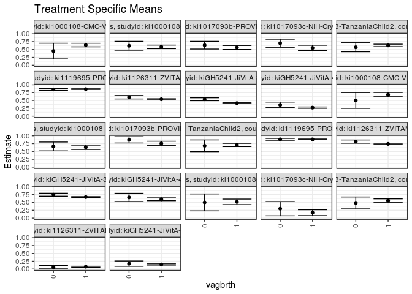

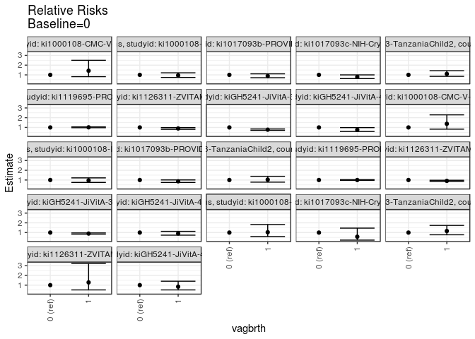

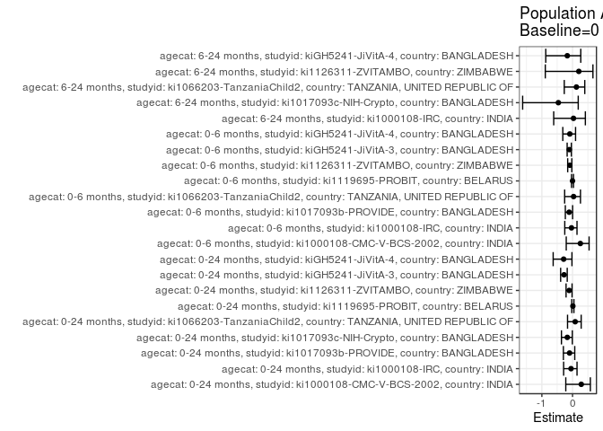

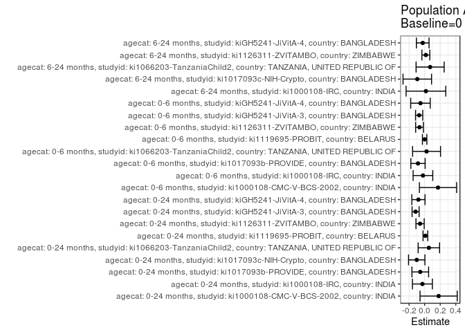

## Results Table

### Parameter: TSM

| agecat | studyid | country | intervention_level | baseline_level | estimate | ci_lower | ci_upper |
| --- | --- | --- | --- | --- | --- | --- | --- |
| 0-24 months | ki1000108-CMC-V-BCS-2002 | INDIA | 0 | NA | 0.4500000 | 0.2010987 | 0.6989013 |
| 0-24 months | ki1000108-CMC-V-BCS-2002 | INDIA | 1 | NA | 0.6414474 | 0.5845014 | 0.6983933 |
| 0-24 months | ki1000108-IRC | INDIA | 0 | NA | 0.6190476 | 0.4772971 | 0.7607982 |
| 0-24 months | ki1000108-IRC | INDIA | 1 | NA | 0.5843373 | 0.5284088 | 0.6402659 |
| 0-24 months | ki1017093b-PROVIDE | BANGLADESH | 0 | NA | 0.6376812 | 0.5149751 | 0.7603872 |
| 0-24 months | ki1017093b-PROVIDE | BANGLADESH | 1 | NA | 0.5648536 | 0.5011691 | 0.6285380 |
| 0-24 months | ki1017093c-NIH-Crypto | BANGLADESH | 0 | NA | 0.7000000 | 0.5714463 | 0.8285537 |
| 0-24 months | ki1017093c-NIH-Crypto | BANGLADESH | 1 | NA | 0.5503876 | 0.4653879 | 0.6353873 |
| 0-24 months | ki1066203-TanzaniaChild2 | TANZANIA, UNITED REPUBLIC OF | 0 | NA | 0.5714286 | 0.4271663 | 0.7156908 |
| 0-24 months | ki1066203-TanzaniaChild2 | TANZANIA, UNITED REPUBLIC OF | 1 | NA | 0.6302003 | 0.5909976 | 0.6694030 |
| 0-24 months | ki1119695-PROBIT | BELARUS | 0 | NA | 0.8518519 | 0.8199332 | 0.8837705 |
| 0-24 months | ki1119695-PROBIT | BELARUS | 1 | NA | 0.8622860 | 0.8516399 | 0.8729321 |
| 0-24 months | ki1126311-ZVITAMBO | ZIMBABWE | 0 | NA | 0.6032787 | 0.5479093 | 0.6586480 |
| 0-24 months | ki1126311-ZVITAMBO | ZIMBABWE | 1 | NA | 0.5386024 | 0.5213719 | 0.5558329 |
| 0-24 months | kiGH5241-JiVitA-3 | BANGLADESH | 0 | NA | 0.5391499 | 0.4925377 | 0.5857621 |
| 0-24 months | kiGH5241-JiVitA-3 | BANGLADESH | 1 | NA | 0.4152113 | 0.4037678 | 0.4266547 |
| 0-24 months | kiGH5241-JiVitA-4 | BANGLADESH | 0 | NA | 0.3587786 | 0.2702149 | 0.4473424 |
| 0-24 months | kiGH5241-JiVitA-4 | BANGLADESH | 1 | NA | 0.2718505 | 0.2498397 | 0.2938613 |
| 0-6 months | ki1000108-CMC-V-BCS-2002 | INDIA | 0 | NA | 0.5000000 | 0.2484317 | 0.7515683 |
| 0-6 months | ki1000108-CMC-V-BCS-2002 | INDIA | 1 | NA | 0.6864865 | 0.6188619 | 0.7541111 |
| 0-6 months | ki1000108-IRC | INDIA | 0 | NA | 0.6595745 | 0.5187984 | 0.8003505 |
| 0-6 months | ki1000108-IRC | INDIA | 1 | NA | 0.6321244 | 0.5625866 | 0.7016621 |
| 0-6 months | ki1017093b-PROVIDE | BANGLADESH | 0 | NA | 0.8695652 | 0.7698152 | 0.9693153 |
| 0-6 months | ki1017093b-PROVIDE | BANGLADESH | 1 | NA | 0.7553957 | 0.6854609 | 0.8253304 |
| 0-6 months | ki1066203-TanzaniaChild2 | TANZANIA, UNITED REPUBLIC OF | 0 | NA | 0.6800000 | 0.4929570 | 0.8670430 |
| 0-6 months | ki1066203-TanzaniaChild2 | TANZANIA, UNITED REPUBLIC OF | 1 | NA | 0.7064516 | 0.6550297 | 0.7578735 |
| 0-6 months | ki1119695-PROBIT | BELARUS | 0 | NA | 0.8858447 | 0.8559825 | 0.9157070 |
| 0-6 months | ki1119695-PROBIT | BELARUS | 1 | NA | 0.8854902 | 0.8753187 | 0.8956617 |
| 0-6 months | ki1126311-ZVITAMBO | ZIMBABWE | 0 | NA | 0.8136364 | 0.7619638 | 0.8653089 |
| 0-6 months | ki1126311-ZVITAMBO | ZIMBABWE | 1 | NA | 0.7409031 | 0.7229421 | 0.7588642 |
| 0-6 months | kiGH5241-JiVitA-3 | BANGLADESH | 0 | NA | 0.7461300 | 0.6986414 | 0.7936187 |
| 0-6 months | kiGH5241-JiVitA-3 | BANGLADESH | 1 | NA | 0.6700000 | 0.6561066 | 0.6838934 |
| 0-6 months | kiGH5241-JiVitA-4 | BANGLADESH | 0 | NA | 0.6600000 | 0.5285681 | 0.7914319 |
| 0-6 months | kiGH5241-JiVitA-4 | BANGLADESH | 1 | NA | 0.6000000 | 0.5551873 | 0.6448127 |
| 6-24 months | ki1000108-IRC | INDIA | 0 | NA | 0.5000000 | 0.2294903 | 0.7705097 |
| 6-24 months | ki1000108-IRC | INDIA | 1 | NA | 0.5179856 | 0.4297875 | 0.6061838 |
| 6-24 months | ki1017093c-NIH-Crypto | BANGLADESH | 0 | NA | 0.3000000 | 0.0725547 | 0.5274453 |
| 6-24 months | ki1017093c-NIH-Crypto | BANGLADESH | 1 | NA | 0.1724138 | 0.0793318 | 0.2654957 |
| 6-24 months | ki1066203-TanzaniaChild2 | TANZANIA, UNITED REPUBLIC OF | 0 | NA | 0.4838710 | 0.2943667 | 0.6733752 |
| 6-24 months | ki1066203-TanzaniaChild2 | TANZANIA, UNITED REPUBLIC OF | 1 | NA | 0.5604720 | 0.5059373 | 0.6150067 |
| 6-24 months | ki1126311-ZVITAMBO | ZIMBABWE | 0 | NA | 0.0588235 | 0.0060316 | 0.1116154 |
| 6-24 months | ki1126311-ZVITAMBO | ZIMBABWE | 1 | NA | 0.0753012 | 0.0590916 | 0.0915108 |
| 6-24 months | kiGH5241-JiVitA-4 | BANGLADESH | 0 | NA | 0.1728395 | 0.0882094 | 0.2574696 |
| 6-24 months | kiGH5241-JiVitA-4 | BANGLADESH | 1 | NA | 0.1459550 | 0.1262576 | 0.1656523 |

### Parameter: E(Y)

| agecat | studyid | country | intervention_level | baseline_level | estimate | ci_lower | ci_upper |
| --- | --- | --- | --- | --- | --- | --- | --- |
| 0-24 months | ki1000108-CMC-V-BCS-2002 | INDIA | NA | NA | 0.6296296 | 0.5734927 | 0.6857666 |
| 0-24 months | ki1000108-IRC | INDIA | NA | NA | 0.5898734 | 0.5376978 | 0.6420491 |
| 0-24 months | ki1017093b-PROVIDE | BANGLADESH | NA | NA | 0.5811688 | 0.5245443 | 0.6377934 |
| 0-24 months | ki1017093c-NIH-Crypto | BANGLADESH | NA | NA | 0.5978836 | 0.5264156 | 0.6693516 |
| 0-24 months | ki1066203-TanzaniaChild2 | TANZANIA, UNITED REPUBLIC OF | NA | NA | 0.6255319 | 0.5876598 | 0.6634040 |
| 0-24 months | ki1119695-PROBIT | BELARUS | NA | NA | 0.8612051 | 0.8511051 | 0.8713052 |
| 0-24 months | ki1126311-ZVITAMBO | ZIMBABWE | NA | NA | 0.5441094 | 0.5276459 | 0.5605730 |
| 0-24 months | kiGH5241-JiVitA-3 | BANGLADESH | NA | NA | 0.4225520 | 0.4114127 | 0.4336913 |
| 0-24 months | kiGH5241-JiVitA-4 | BANGLADESH | NA | NA | 0.2782123 | 0.2567662 | 0.2996583 |
| 0-6 months | ki1000108-CMC-V-BCS-2002 | INDIA | NA | NA | 0.6716418 | 0.6057305 | 0.7375531 |
| 0-6 months | ki1000108-IRC | INDIA | NA | NA | 0.6375000 | 0.5751450 | 0.6998550 |
| 0-6 months | ki1017093b-PROVIDE | BANGLADESH | NA | NA | 0.7837838 | 0.7252863 | 0.8422812 |
| 0-6 months | ki1066203-TanzaniaChild2 | TANZANIA, UNITED REPUBLIC OF | NA | NA | 0.7044776 | 0.6548846 | 0.7540707 |
| 0-6 months | ki1119695-PROBIT | BELARUS | NA | NA | 0.8855266 | 0.8758983 | 0.8951550 |
| 0-6 months | ki1126311-ZVITAMBO | ZIMBABWE | NA | NA | 0.7473011 | 0.7302821 | 0.7643201 |
| 0-6 months | kiGH5241-JiVitA-3 | BANGLADESH | NA | NA | 0.6752064 | 0.6618507 | 0.6885622 |
| 0-6 months | kiGH5241-JiVitA-4 | BANGLADESH | NA | NA | 0.6058824 | 0.5634305 | 0.6483342 |
| 6-24 months | ki1000108-IRC | INDIA | NA | NA | 0.5161290 | 0.4322562 | 0.6000019 |
| 6-24 months | ki1017093c-NIH-Crypto | BANGLADESH | NA | NA | 0.2051282 | 0.1132549 | 0.2970015 |
| 6-24 months | ki1066203-TanzaniaChild2 | TANZANIA, UNITED REPUBLIC OF | NA | NA | 0.5540541 | 0.5015831 | 0.6065250 |
| 6-24 months | ki1126311-ZVITAMBO | ZIMBABWE | NA | NA | 0.0740056 | 0.0585029 | 0.0895082 |
| 6-24 months | kiGH5241-JiVitA-4 | BANGLADESH | NA | NA | 0.1476563 | 0.1284384 | 0.1668741 |

### Parameter: RR

| agecat | studyid | country | intervention_level | baseline_level | estimate | ci_lower | ci_upper |
| --- | --- | --- | --- | --- | --- | --- | --- |
| 0-24 months | ki1000108-CMC-V-BCS-2002 | INDIA | 0 | 0 | 1.0000000 | 1.0000000 | 1.0000000 |
| 0-24 months | ki1000108-CMC-V-BCS-2002 | INDIA | 1 | 0 | 1.4254386 | 0.8141162 | 2.4958048 |
| 0-24 months | ki1000108-IRC | INDIA | 0 | 0 | 1.0000000 | 1.0000000 | 1.0000000 |
| 0-24 months | ki1000108-IRC | INDIA | 1 | 0 | 0.9439296 | 0.7364714 | 1.2098271 |
| 0-24 months | ki1017093b-PROVIDE | BANGLADESH | 0 | 0 | 1.0000000 | 1.0000000 | 1.0000000 |
| 0-24 months | ki1017093b-PROVIDE | BANGLADESH | 1 | 0 | 0.8857931 | 0.7086201 | 1.1072638 |
| 0-24 months | ki1017093c-NIH-Crypto | BANGLADESH | 0 | 0 | 1.0000000 | 1.0000000 | 1.0000000 |
| 0-24 months | ki1017093c-NIH-Crypto | BANGLADESH | 1 | 0 | 0.7862680 | 0.6183979 | 0.9997081 |
| 0-24 months | ki1066203-TanzaniaChild2 | TANZANIA, UNITED REPUBLIC OF | 0 | 0 | 1.0000000 | 1.0000000 | 1.0000000 |
| 0-24 months | ki1066203-TanzaniaChild2 | TANZANIA, UNITED REPUBLIC OF | 1 | 0 | 1.1028505 | 0.8503520 | 1.4303246 |
| 0-24 months | ki1119695-PROBIT | BELARUS | 0 | 0 | 1.0000000 | 1.0000000 | 1.0000000 |
| 0-24 months | ki1119695-PROBIT | BELARUS | 1 | 0 | 1.0122488 | 0.9730912 | 1.0529821 |
| 0-24 months | ki1126311-ZVITAMBO | ZIMBABWE | 0 | 0 | 1.0000000 | 1.0000000 | 1.0000000 |
| 0-24 months | ki1126311-ZVITAMBO | ZIMBABWE | 1 | 0 | 0.8927920 | 0.8100947 | 0.9839313 |
| 0-24 months | kiGH5241-JiVitA-3 | BANGLADESH | 0 | 0 | 1.0000000 | 1.0000000 | 1.0000000 |
| 0-24 months | kiGH5241-JiVitA-3 | BANGLADESH | 1 | 0 | 0.7701221 | 0.7033173 | 0.8432725 |
| 0-24 months | kiGH5241-JiVitA-4 | BANGLADESH | 0 | 0 | 1.0000000 | 1.0000000 | 1.0000000 |
| 0-24 months | kiGH5241-JiVitA-4 | BANGLADESH | 1 | 0 | 0.7577110 | 0.5843602 | 0.9824864 |
| 0-6 months | ki1000108-CMC-V-BCS-2002 | INDIA | 0 | 0 | 1.0000000 | 1.0000000 | 1.0000000 |
| 0-6 months | ki1000108-CMC-V-BCS-2002 | INDIA | 1 | 0 | 1.3729730 | 0.8222475 | 2.2925636 |
| 0-6 months | ki1000108-IRC | INDIA | 0 | 0 | 1.0000000 | 1.0000000 | 1.0000000 |
| 0-6 months | ki1000108-IRC | INDIA | 1 | 0 | 0.9583821 | 0.7537882 | 1.2185071 |
| 0-6 months | ki1017093b-PROVIDE | BANGLADESH | 0 | 0 | 1.0000000 | 1.0000000 | 1.0000000 |
| 0-6 months | ki1017093b-PROVIDE | BANGLADESH | 1 | 0 | 0.8687050 | 0.7496395 | 1.0066819 |
| 0-6 months | ki1066203-TanzaniaChild2 | TANZANIA, UNITED REPUBLIC OF | 0 | 0 | 1.0000000 | 1.0000000 | 1.0000000 |
| 0-6 months | ki1066203-TanzaniaChild2 | TANZANIA, UNITED REPUBLIC OF | 1 | 0 | 1.0388994 | 0.7816335 | 1.3808416 |
| 0-6 months | ki1119695-PROBIT | BELARUS | 0 | 0 | 1.0000000 | 1.0000000 | 1.0000000 |
| 0-6 months | ki1119695-PROBIT | BELARUS | 1 | 0 | 0.9995998 | 0.9646267 | 1.0358408 |
| 0-6 months | ki1126311-ZVITAMBO | ZIMBABWE | 0 | 0 | 1.0000000 | 1.0000000 | 1.0000000 |
| 0-6 months | ki1126311-ZVITAMBO | ZIMBABWE | 1 | 0 | 0.9106072 | 0.8507633 | 0.9746606 |
| 0-6 months | kiGH5241-JiVitA-3 | BANGLADESH | 0 | 0 | 1.0000000 | 1.0000000 | 1.0000000 |
| 0-6 months | kiGH5241-JiVitA-3 | BANGLADESH | 1 | 0 | 0.8979668 | 0.8398251 | 0.9601337 |
| 0-6 months | kiGH5241-JiVitA-4 | BANGLADESH | 0 | 0 | 1.0000000 | 1.0000000 | 1.0000000 |
| 0-6 months | kiGH5241-JiVitA-4 | BANGLADESH | 1 | 0 | 0.9090909 | 0.7349192 | 1.1245403 |
| 6-24 months | ki1000108-IRC | INDIA | 0 | 0 | 1.0000000 | 1.0000000 | 1.0000000 |
| 6-24 months | ki1000108-IRC | INDIA | 1 | 0 | 1.0359712 | 0.5874383 | 1.8269773 |
| 6-24 months | ki1017093c-NIH-Crypto | BANGLADESH | 0 | 0 | 1.0000000 | 1.0000000 | 1.0000000 |
| 6-24 months | ki1017093c-NIH-Crypto | BANGLADESH | 1 | 0 | 0.5747126 | 0.2266054 | 1.4575764 |
| 6-24 months | ki1066203-TanzaniaChild2 | TANZANIA, UNITED REPUBLIC OF | 0 | 0 | 1.0000000 | 1.0000000 | 1.0000000 |
| 6-24 months | ki1066203-TanzaniaChild2 | TANZANIA, UNITED REPUBLIC OF | 1 | 0 | 1.1583088 | 0.7736858 | 1.7341395 |
| 6-24 months | ki1126311-ZVITAMBO | ZIMBABWE | 0 | 0 | 1.0000000 | 1.0000000 | 1.0000000 |
| 6-24 months | ki1126311-ZVITAMBO | ZIMBABWE | 1 | 0 | 1.2801205 | 0.5086675 | 3.2215712 |
| 6-24 months | kiGH5241-JiVitA-4 | BANGLADESH | 0 | 0 | 1.0000000 | 1.0000000 | 1.0000000 |
| 6-24 months | kiGH5241-JiVitA-4 | BANGLADESH | 1 | 0 | 0.8444537 | 0.5081533 | 1.4033206 |

### Parameter: PAR

| agecat | studyid | country | intervention_level | baseline_level | estimate | ci_lower | ci_upper |
| --- | --- | --- | --- | --- | --- | --- | --- |
| 0-24 months | ki1000108-CMC-V-BCS-2002 | INDIA | 0 | NA | 0.1796296 | -0.0595047 | 0.4187640 |
| 0-24 months | ki1000108-IRC | INDIA | 0 | NA | -0.0291742 | -0.1572589 | 0.0989105 |
| 0-24 months | ki1017093b-PROVIDE | BANGLADESH | 0 | NA | -0.0565123 | -0.1637092 | 0.0506845 |
| 0-24 months | ki1017093c-NIH-Crypto | BANGLADESH | 0 | NA | -0.1021164 | -0.2073521 | 0.0031193 |
| 0-24 months | ki1066203-TanzaniaChild2 | TANZANIA, UNITED REPUBLIC OF | 0 | NA | 0.0541033 | -0.0835572 | 0.1917639 |
| 0-24 months | ki1119695-PROBIT | BELARUS | 0 | NA | 0.0093533 | -0.0208102 | 0.0395168 |
| 0-24 months | ki1126311-ZVITAMBO | ZIMBABWE | 0 | NA | -0.0591693 | -0.1122107 | -0.0061278 |
| 0-24 months | kiGH5241-JiVitA-3 | BANGLADESH | 0 | NA | -0.1165979 | -0.1617459 | -0.0714498 |
| 0-24 months | kiGH5241-JiVitA-4 | BANGLADESH | 0 | NA | -0.0805663 | -0.1651393 | 0.0040066 |
| 0-6 months | ki1000108-CMC-V-BCS-2002 | INDIA | 0 | NA | 0.1716418 | -0.0677857 | 0.4110693 |
| 0-6 months | ki1000108-IRC | INDIA | 0 | NA | -0.0220745 | -0.1483923 | 0.1042433 |
| 0-6 months | ki1017093b-PROVIDE | BANGLADESH | 0 | NA | -0.0857814 | -0.1775631 | 0.0060003 |
| 0-6 months | ki1066203-TanzaniaChild2 | TANZANIA, UNITED REPUBLIC OF | 0 | NA | 0.0244776 | -0.1550298 | 0.2039850 |
| 0-6 months | ki1119695-PROBIT | BELARUS | 0 | NA | -0.0003181 | -0.0286238 | 0.0279876 |
| 0-6 months | ki1126311-ZVITAMBO | ZIMBABWE | 0 | NA | -0.0663353 | -0.1162347 | -0.0164358 |
| 0-6 months | kiGH5241-JiVitA-3 | BANGLADESH | 0 | NA | -0.0709236 | -0.1170223 | -0.0248249 |
| 0-6 months | kiGH5241-JiVitA-4 | BANGLADESH | 0 | NA | -0.0541176 | -0.1793749 | 0.0711396 |
| 6-24 months | ki1000108-IRC | INDIA | 0 | NA | 0.0161290 | -0.2390237 | 0.2712818 |
| 6-24 months | ki1017093c-NIH-Crypto | BANGLADESH | 0 | NA | -0.0948718 | -0.2780930 | 0.0883494 |
| 6-24 months | ki1066203-TanzaniaChild2 | TANZANIA, UNITED REPUBLIC OF | 0 | NA | 0.0701831 | -0.1104929 | 0.2508590 |
| 6-24 months | ki1126311-ZVITAMBO | ZIMBABWE | 0 | NA | 0.0151820 | -0.0357019 | 0.0660660 |
| 6-24 months | kiGH5241-JiVitA-4 | BANGLADESH | 0 | NA | -0.0251833 | -0.1065802 | 0.0562137 |

### Parameter: PAF

| agecat | studyid | country | intervention_level | baseline_level | estimate | ci_lower | ci_upper |
| --- | --- | --- | --- | --- | --- | --- | --- |
| 0-24 months | ki1000108-CMC-V-BCS-2002 | INDIA | 0 | NA | 0.2852941 | -0.2199966 | 0.5813066 |
| 0-24 months | ki1000108-IRC | INDIA | 0 | NA | -0.0494584 | -0.2903597 | 0.1464683 |
| 0-24 months | ki1017093b-PROVIDE | BANGLADESH | 0 | NA | -0.0972391 | -0.2980557 | 0.0725100 |
| 0-24 months | ki1017093c-NIH-Crypto | BANGLADESH | 0 | NA | -0.1707965 | -0.3615619 | -0.0067587 |
| 0-24 months | ki1066203-TanzaniaChild2 | TANZANIA, UNITED REPUBLIC OF | 0 | NA | 0.0864917 | -0.1627010 | 0.2822769 |
| 0-24 months | ki1119695-PROBIT | BELARUS | 0 | NA | 0.0108607 | -0.0247933 | 0.0452742 |
| 0-24 months | ki1126311-ZVITAMBO | ZIMBABWE | 0 | NA | -0.1087451 | -0.2107411 | -0.0153415 |
| 0-24 months | kiGH5241-JiVitA-3 | BANGLADESH | 0 | NA | -0.2759373 | -0.3875730 | -0.1732832 |
| 0-24 months | kiGH5241-JiVitA-4 | BANGLADESH | 0 | NA | -0.2895858 | -0.6316280 | -0.0192468 |
| 0-6 months | ki1000108-CMC-V-BCS-2002 | INDIA | 0 | NA | 0.2555556 | -0.2051932 | 0.5401588 |
| 0-6 months | ki1000108-IRC | INDIA | 0 | NA | -0.0346266 | -0.2530595 | 0.1457291 |
| 0-6 months | ki1017093b-PROVIDE | BANGLADESH | 0 | NA | -0.1094453 | -0.2348561 | 0.0032289 |
| 0-6 months | ki1066203-TanzaniaChild2 | TANZANIA, UNITED REPUBLIC OF | 0 | NA | 0.0347458 | -0.2569309 | 0.2587375 |
| 0-6 months | ki1119695-PROBIT | BELARUS | 0 | NA | -0.0003592 | -0.0328402 | 0.0311003 |
| 0-6 months | ki1126311-ZVITAMBO | ZIMBABWE | 0 | NA | -0.0887665 | -0.1578004 | -0.0238487 |
| 0-6 months | kiGH5241-JiVitA-3 | BANGLADESH | 0 | NA | -0.1050399 | -0.1755868 | -0.0387265 |
| 0-6 months | kiGH5241-JiVitA-4 | BANGLADESH | 0 | NA | -0.0893204 | -0.3172442 | 0.0991656 |
| 6-24 months | ki1000108-IRC | INDIA | 0 | NA | 0.0312500 | -0.6139924 | 0.4185372 |
| 6-24 months | ki1017093c-NIH-Crypto | BANGLADESH | 0 | NA | -0.4625000 | -1.6271554 | 0.1858471 |
| 6-24 months | ki1066203-TanzaniaChild2 | TANZANIA, UNITED REPUBLIC OF | 0 | NA | 0.1266719 | -0.2694429 | 0.3991837 |
| 6-24 months | ki1126311-ZVITAMBO | ZIMBABWE | 0 | NA | 0.2051471 | -0.8882704 | 0.6654127 |
| 6-24 months | kiGH5241-JiVitA-4 | BANGLADESH | 0 | NA | -0.1705533 | -0.8734516 | 0.2686254 |